[PROJECTS/PROGRAMS](http://www.nist.gov/laboratories/projects-programs)

# IREX 10: Identification Track

[output not shown]

## Leaderboard

|  | Developer | Accuracy (FNIR) | Search Time (s) | Template Creation Time (s) | Submission Date |
| --- | --- | --- | --- | --- | --- |
| 1 | Neurotechnology | 0.0062 ± 0.0004 | 8.1 ± 0.2 | 0.05 ± 0.01 | Oct 2019 |
| 2 | NEC | 0.0119 ± 0.0006 | 9 ± 3 | 1.02 ± 0.09 | Nov 2019 |

Table Legend

| Accuracy Metric: | *[FNIR](https://www.nist.gov/itl/iad/ig/irex-10-performance-metrics) (i.e., ‘miss rate’) at an FPIR of 0.01 (± 90% confidence)* |
| --- | --- |
| Dataset: | [*Operational Dataset 4*](https://www.nist.gov/itl/iad/image-group/irex-datasets) |
| Samples used: | *Both eyes* |
| Enrolled Population: | *500K people* |
| Enrollment Method: | *One enrollment session per person* |

The number after the ± indicates either the 90% confidence (for accuracy) or the standard deviation (for timing results).

## Detection-Error Trade-off Plots

Core accuracy for the identification task can be characterized by [Detection-error trade-off (DET) plots](https://www.nist.gov/itl/iad/ig/irex-10-performance-metrics). Generally, curves lower down in a DET plot correspond to more accurate matchers. Click on the links below to view DETs for two-eye matching (left) and single-eye matching (right).

| Samples used: | *Both eyes* |
| --- | --- |
| Enrolled population: | *500K people* |
| Enrollment method: | *One session* |

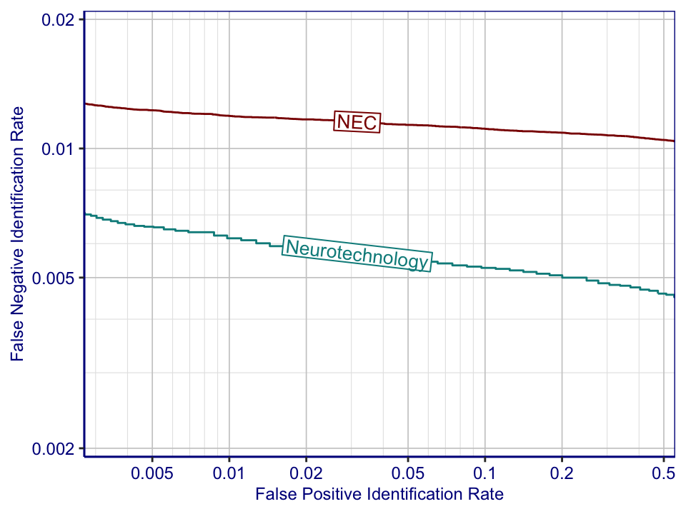

| Samples used: | *One eye* |
| --- | --- |
| Enrolled population: | *1M distinct eyes* |
| Enrollment method: | *One session* |

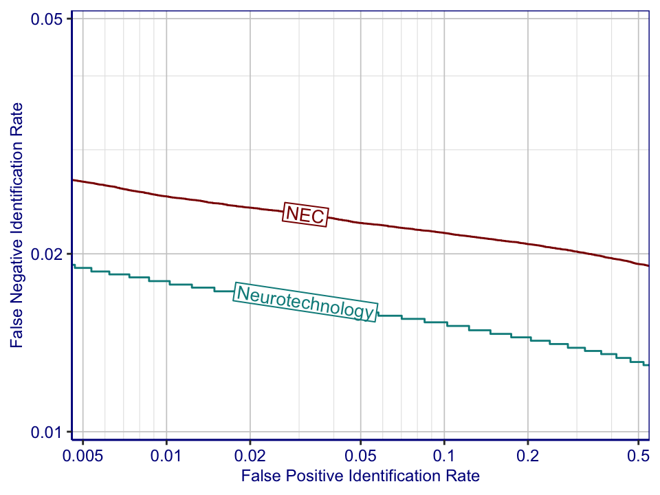

## Rank-based Accuracy

Rank-based metrics quantify accuracy for *closed-set* applications, where it can be guaranteed that every searched individual is enrolled. The rank 10 “hit rate” is the fraction of searches that return the correct result within the top 10 candidates. The miss rate is one minus the hit rate.

|  | Developer | Rank 1 Miss Rate | Rank 10 Miss Rate | Rank 100 Miss Rate | Submission Date |
| --- | --- | --- | --- | --- | --- |
| 1 | Neurotechnology | 0.0057 | 0.0038 | 0.0035 | Oct 2019 |
| 2 | NEC | 0.0117 | 0.01 | 0.0098 | Nov 2019 |

Table Legend

| Dataset: | [*Operational Dataset 4*](https://www.nist.gov/itl/iad/image-group/irex-datasets) |
| --- | --- |
| Samples used: | *Both eyes* |
| Enrolled Population: | *500K people* |
| Enrollment Method: | *One enrollment session per person* |

## Computation Time

Computation times are measured as the the elapsed real time (i.e., “wall clock” time) as opposed to CPU time. Timing estimates were computed on unloaded machines with only a single process dedicated to biometric operations. The test machines are [Dell PowerEdge M910](https://www.dell.com/downloads/global/products/pedge/M910_Spec_Sheet.pdf) blades with Dual Intel Xeon X7560 2.3 GHz CPUs (eight cores per processor).

*Search Time*

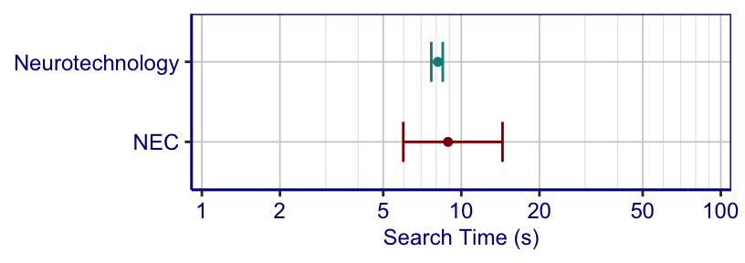

*Template Creation Time*

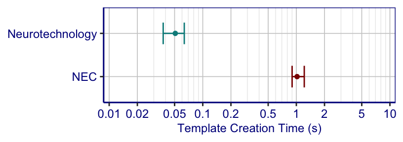

**HEADQUARTERS**